# Tarea 2 Modelos Lineales

## 2. Según el gráfico de **Correlación** ¿cuál es la variable que mejor correlaciona con la variable a predecir?

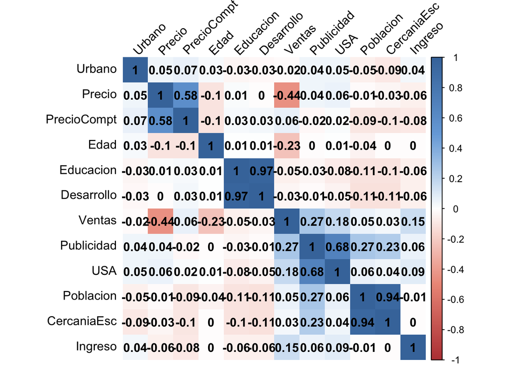

```r
library(corrplot)
datos2 <- datos[,-8]
matriz.correlacion<-cor(datos2)

col <- colorRampPalette(c("#BB4444", "#EE9988", "#FFFFFF", "#77AADD", "#4477AA"))
corrplot(matriz.correlacion, method="shade", shade.col=NA, tl.col="black", tl.srt=45,
col=col(200), addCoef.col="black", order="AOE")
```

```r
library("ggplot2")
```

La variable que se relaciona mejor con la variable a predecir es `Precio`, seguido de `Publicidad` y después `Edad`.

## 3. Ejecute una Regresión Lineal y usando el valor absoluto de los coeficientes β determine cuáles son las 5 variables que mayor importancia tienen en la regresión. ¿Está la variables que tenía mayor poder predictivo según los dos ejercicios anteriores?

```r
modelo.lm <- lm(Ventas~., data = datos)

#betas
coef(modelo.lm)
```

```
       (Intercept)        PrecioCompt            Ingreso        CercaniaEsc         Publicidad          Poblacion             Precio  CalidadEstantMalo CalidadEstantMedio               Edad          Educacion             Urbano                USA         Desarrollo
      10.703850632        0.092883073        0.015843862       -0.534727041        0.122817132        0.001316293       -0.095442522       -4.843705164       -2.885654507       -0.045621689       -0.044684588        0.107866479       -0.189422371        0.184867405
```

```r
numero.predictoras <- dim(datos)[2] - 1

numero.filas <- dim(datos)[1]

pred <- predict(modelo.lm,datos.prueba)

indices.calidad <- indices.precision(datos.prueba$Ventas,pred,numero.predictoras)
indices.calidad
```

```
$error.cuadratico
[1] 1.084442

$raiz.error.cuadratico
[1] 1.116461

$error.relativo
[1] 0.1093815

$correlacion
[1] 0.9135059
```

## 4. Corra un modelo de Regresión Penalizada tipo Lasso ¿Cuáles variables se anulan y por qué? ¿Cuál modelo prefiere Regresión Lineal o Lasso? Según lo anterior y basado en los índices de calidad de ambos métodos, justifique su respuesta. Nota: Debido a los procesos de optimización que se ejecutan dentro del método Lasso dos ejecuciones de este item podrían dar diferente, además podría causar que en alguna de las ejecuciones no se anule ningún β (coeficiente).

```r
library(glmnet)

x<- model.matrix(Ventas~.,datos)[,-1]
y<-datos$Ventas

options(max.print = 2000,width=2000)


# Usando validación cruzada para determinar el mejor Lambda
sal.cv<-cv.glmnet(x,y,alpha=0)

# Construye el Modelo LASSO
lasso.mod<-glmnet(x,y,alpha=1)


x.datos.prueba<-model.matrix(Ventas~.,datos.prueba)[,-1]

mejor.lambda<-sal.cv$lambda.min
mejor.lambda
```

```
[1] 0.125502
```

```r
coef(lasso.mod)[,which(lasso.mod$lambda==mejor.lambda)]
```

```
14 x 0 sparse Matrix of class "dgCMatrix"

(Intercept)
PrecioCompt
Ingreso
CercaniaEsc
Publicidad
Poblacion
Precio
CalidadEstantMalo
CalidadEstantMedio
Edad
Educacion
Urbano
USA
Desarrollo
```

```r
pred1<-predict(lasso.mod,s=mejor.lambda,newx=x.datos.prueba,type = "coefficients")

pred<-predict(lasso.mod,s=mejor.lambda,newx=x.datos.prueba)

numero.predictoras <- dim(datos)[2] - 1

numero.filas <- dim(datos)[1]


indices.calidad <- indices.precision(datos.prueba$Ventas,pred,numero.predictoras)
indices.calidad
```

```
$error.cuadratico
[1] 1.166224

$raiz.error.cuadratico
[1] 1.157794

$error.relativo
[1] 0.1096895

$correlacion
[1] 0.9116523
```

```r
pred1
```

```
14 x 1 sparse Matrix of class "dgCMatrix"
                            s1
(Intercept)        10.72406973
PrecioCompt         0.07215587
Ingreso             0.01107424
CercaniaEsc         .
Publicidad          0.09744863
Poblacion           .
Precio             -0.08122280
CalidadEstantMalo  -4.04702233
CalidadEstantMedio -2.23494335
Edad               -0.03848684
Educacion           .
Urbano              .
USA                 .
Desarrollo          .
```

Se anularon 6 variables.

La correlación de Regresión Lineal es mayor por poco, pero la cantidad de variables que utiliza LASSO es menor, por esto la interpretabilidad es más sencilla. Prefiero el modelo de LASSO.

## 6. En el caso de la variable `CalidadEstant` `R` también automáticamente la convierte en Códigos Disyuntivos Completos (Variables Dummies), solo aparecen las modalidades `CantidadEstantMalo` y `CantidadEstantMedio` porque la tercera categoría Bueno es complementaria a las dos anteriores.

¿Qué sucede si en `R` forzamos a la variable `CantidadEstant` a ser variable Código Disyuntivo Completo (Dummy)? Nótese que en R cuando se recodifica una variable hay que generar de nuevo las tablas de training-testing.

```r
#dummy las categoricas no ordinales
datos <- dummy_cols(datos, select_columns = c("CalidadEstant"),remove_selected_columns = T)

#factor las categoricas ordinales
#datos$CalidadEstant <- factor(datos$CalidadEstant, levels = #c("Malo","Medio","Bueno"))

numero.columnas <- dim(datos)[2]
numero.filas <- dim(datos)[1]
muestra <- sample(1:numero.filas,numero.filas*0.25)
datos.aprendizaje <- datos[-muestra, ]
datos.prueba <- datos[muestra, ]

x<-model.matrix(Ventas~.,datos)[,-1]
y<-datos$Ventas

options(max.print = 2000,width=2000)
# Construye el Modelo LASSO
lasso.mod<-glmnet(x,y,alpha=1)
coef(lasso.mod)
```

[output not shown]

```r
x.datos.prueba<-model.matrix(Ventas~.,datos.prueba)[,-1]
# Usando validación cruzada para determinar el mejor Lambda
sal.cv<-cv.glmnet(x,y,alpha=0)

mejor.lambda<-sal.cv$lambda.min
mejor.lambda
```

```
[1] 0.141173
```

```r
coef(lasso.mod)[,which(lasso.mod$lambda==mejor.lambda)]
```

```
15 x 0 sparse Matrix of class "dgCMatrix"

(Intercept)
PrecioCompt
Ingreso
CercaniaEsc
Publicidad
Poblacion
Precio
Edad
Educacion
Urbano
USA
Desarrollo
CalidadEstant_Bueno
CalidadEstant_Malo
CalidadEstant_Medio
```

```r
pred<-predict(lasso.mod,s=mejor.lambda,newx=x.datos.prueba)

numero.predictoras <- dim(datos)[2] - 1


indices.calidad <- indices.precision(datos.prueba$Ventas,pred,numero.predictoras)
indices.calidad
```

```
$error.cuadratico
[1] 1.294171

$raiz.error.cuadratico
[1] 1.233918

$error.relativo
[1] 0.1256478

$correlacion
[1] 0.9348036
```

# Pregunta 5

## 1. Programe en **R** una función `lm2(...)` que recibe como parámetro una tabla de aprendizaje y retorna un modelo de Regresión Lineal, es decir, calcula y retorna $β = (X^tX)^{−1}X^ty$.

```r
lm2 <- function(datos.training, y) {
  X <- as.matrix(datos.training[-ncol(datos.training)])
  X <- cbind(rep(1, length(y)), X)
  return(solve(t(X) %*% X) %*% (t(X) %*% y))
}
```

## 2. Programe en **R** una función `predict2(...)` que recibe como parámetro el modelo construido en la pregunta anterior, una tabla de testing de modo tal que retorna la predicción para esta tabla de testing.

```r
predict2 <- function(modelo, tabla) {
  tabla.predictoras <- ttesting[rownames(model2)[-1]]
  table <- as.matrix(tabla.predictoras)
  return(modelo[1] + table[,-103] %*% modelo[-1])
}
```

## 3. Usando la tabla de datos `uscrime.csv` compare los resultados de las funciones `lm(...)`, `lm2(...)`, `predict(...)` y `predict2(...)`.

```r
library(dummies)

datos <- read.table('Datos/uscrime.csv',header=TRUE, sep=',',dec='.')

cantidad.variables.predictoras <- dim(datos)[2] - 1
cantidad.filas <- dim(datos)[1]
datos.muestra <- sample(1:cantidad.filas,cantidad.filas*0.80)
ttraining <- datos[datos.muestra,]
ttesting <- datos[-datos.muestra,]
```

### lm

```r
model2 <- lm2(ttraining, ttraining$ViolentCrimesPerPop)
model1 <- lm(ViolentCrimesPerPop~., ttraining)

data.frame(modelo.lm = model1$coefficients, modelo.lm2 = model2)
```

|  | modelo.lm | modelo.lm2 |
| --- | --- | --- |
| (Intercept) | 0.3825706818 | 0.3825706818 |
| state | -0.0009389047 | -0.0009389047 |
| fold | -0.0012780799 | -0.0012780799 |
| population | 0.3682396789 | 0.3682396788 |
| householdsize | 0.0135637494 | 0.0135637494 |
| racepctblack | 0.2214419816 | 0.2214419816 |
| racePctWhite | 0.0185136688 | 0.0185136688 |
| racePctAsian | 0.0158074761 | 0.0158074761 |
| racePctHisp | 0.0516736228 | 0.0516736228 |
| agePct12t21 | 0.1044304348 | 0.1044304348 |

[output cut: 93 more lines]

### predict

```r
predic2 <- predict2(model2, ttesting)

predic1 <- predict(model1, ttesting)

data.frame(predict = predic1, predict2 = predic2)
```

|  | predict | predict2 |
| --- | --- | --- |
| 4 | 0.28984428 | 0.28984428 |
| 6 | 0.23288841 | 0.23288841 |
| 13 | 0.04660419 | 0.04660419 |
| 27 | 0.60358089 | 0.60358089 |
| 28 | 0.10879419 | 0.10879419 |
| 31 | 0.14554479 | 0.14554479 |
| 36 | 0.32790938 | 0.32790938 |
| 38 | 0.14944522 | 0.14944522 |
| 42 | 0.08199488 | 0.08199488 |
| 44 | 0.40478577 | 0.40478577 |

[output cut: 65 more lines]

## 4. Usando la tabla de datos `uscrime.csv` y la función de **R** denominada `system.time(...)` compare los tiempos de ejecución de las funciones `lm(...)`, `lm2(...)`, `predict(...)` y `predict2(...)`.

```r
time1 <- head(system.time(lm(ViolentCrimesPerPop~., ttraining)), 3)
time2 <- head(system.time(lm2(ttraining, ttraining$ViolentCrimesPerPop)), 3)

data.frame(Tiempo.lm = time1, Tiempo.lm2 = time2)
```

|  | Tiempo.lm | Tiempo.lm2 |
| --- | --- | --- |
| user.self | 0.027 | 0.015 |
| sys.self | 0.002 | 0.000 |
| elapsed | 0.030 | 0.017 |